# Part II - ProsperLoanData

## by Edeh, Chinonso James

## Investigation Overview

In this presentation, I will focus on answering the research questions that was proposed at the begining of the analysis;

- What factors affect a loan's outcome status?
- Are there differences between loans depending on how large the original loan amount was?

Then, the list of findings I got from my investigation were presented.

## (What factors affect a loan's outcome status?)

> The IncomeRange and EmploymentStatus are strong factors that affects the outcome of loans. It is observed that IncomeRange of 25,000 - 49,999 and 50,000 - 74,9999 varies mostly with the LoanStatus. Also, the EmploymentStatus of Employed and Full-time show strong variation with the LoanStatus, especially in the category of completed loans and current loans.

#### To investigate the features Associated with the Current LoanStatus

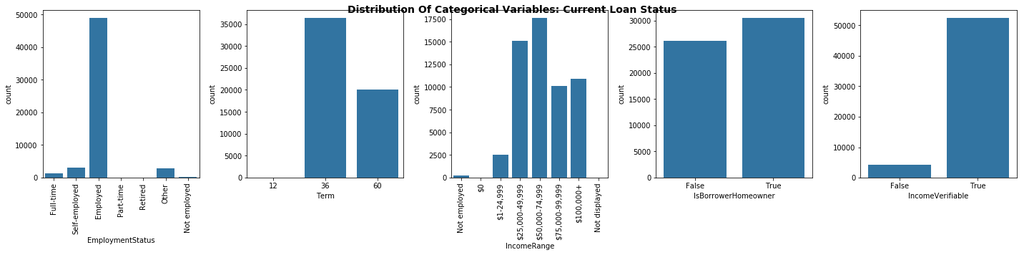

The chart above is a subplots of variables for the Current LoanStatus dataset.

> The EmploymentStatus subplot shows that there are more number of borrowers with 'Employed' EmployedStatus. There is significant low value for the other status with 'Part-timed' being the least of all.

> The 'Term' subplot shows that the number of borrowers that took 36 term has higher value than the 60 Term. Very low value took 12 Term.

> IncomeRange of 50,000-74,999 has the highest counts of borrower, followed by 25,000 - 49,9999

> There are more borrowers that are Homeowner.

> More number of borrowers have their Income verified.

#### To investigate the features Associated with the Completed LoanStatus

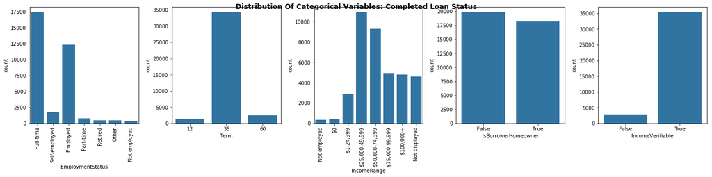

The chart above is a subplots of variables for the completed LoanStatus dataset.

> The EmploymentStatus subplot shows that there are more number of borrowers with 'Full-time' and 'Employed' EmployedStatus. There is significant low value for the other status with 'Not employed' being the least of all.

> The 'Term' subplot shows that the number of borrowers that took 36 term is way more higher than the rest 60 and 12 terms

> IncomeRange of 25,000-49,999 has the highest counts of borrower, followed by 50,000 - 74,9999

> There is a close value of True/False for counts of 'IsBorrowerHomeowner

> More number of borrowers have their Income verified.

#### To investigate the features Associated with the Chargedoff LoanStatus

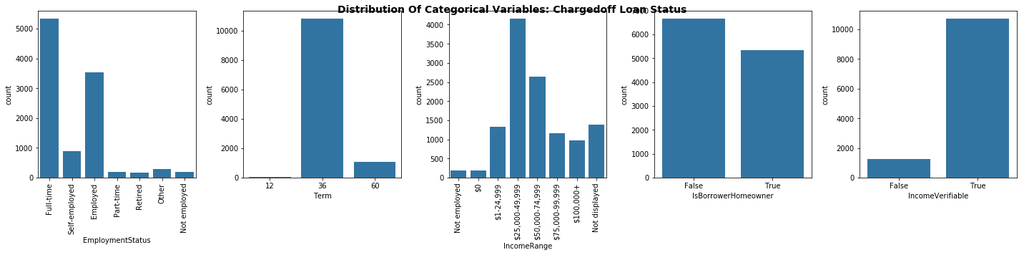

The chart above is a subplots of variables for the Chargedoff LoanStatus dataset.

> The EmploymentStatus subplot shows that there are more number of borrowers with 'Full-time' and 'Employed' EmployedStatus. There is significant low value for the other status with 'Retired' being the least of all.

> The 'Term' subplot shows that the number of borrowers that took 36 term is way more higher than the rest 60 and 12 terms

> IncomeRange of 25,000-49,999 has the highest counts of borrower, followed by 50,000 - 74,9999

> More number of borrowers have their Income verified.

#### To investigate the features Associated with the Defaulted LoanStatus

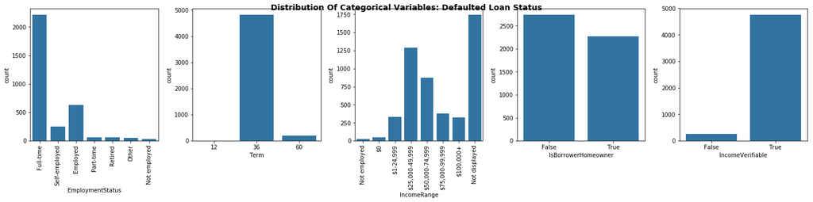

The chart above is a subplots of variables for the Defaulted LoanStatus dataset.

> The EmploymentStatus subplot shows that there are more number of borrowers with 'Full-time' EmployedStatus. There is significant low value for the other status with 'Not employed' being the least of all.

> The 'Term' subplot shows that the number of borrowers that took 36 term is way more higher than the rest 60 and 12 terms

> More number of borrowers have their Income verified.

#### To investigate the features Associated with the Cancelled LoanStatus

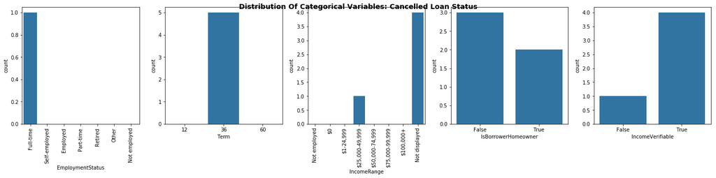

The chart above is a subplots of variables for the Cancelled LoanStatus dataset.

## (Are there differences between loans depending on how large the original loan amount was?)

#### To Investigate the relationship between Term and LoanOriginalAmount

```
Text(0.5,1,'Plot of Term against LoanOriginalAmount')
```

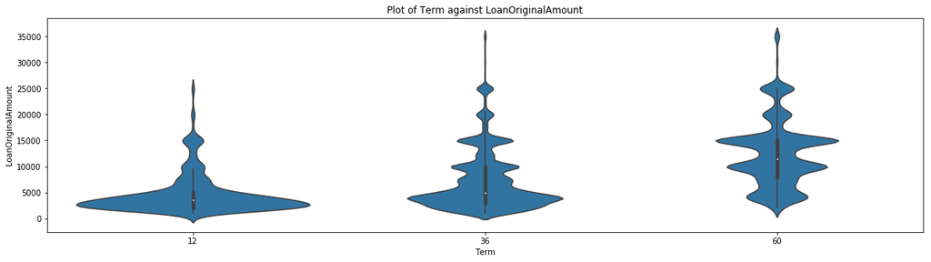

The plot above shows the relationship between the Term variable and the LoanOriginalAmount.

> For Term 12, there are several borrowers with LoanOriginalAmount below 5000.

> For the 36 Term, borrowers are more at the region below 5000 LoanOriginalAmount, few between 5000 and 10000, also between 10000 and 15000.

> For the 60 Term, there are more borrowers at the upper region of LoanOriginalAmount. Points between 15000 and 10000 has more borrowers, followed by 10000 and 5000, then below 5000.

#### To Investigate the relationship between LoanStatus and LoanOriginalAmount

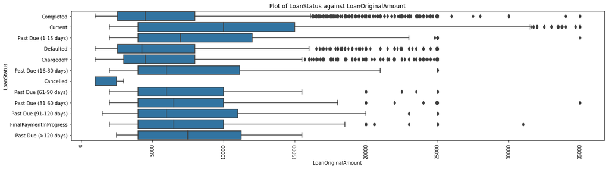

The plot above shows the relationship between LoanStatus and LoanOriginalAmount.

> The completed LoanStatus has values of LoanOriginalAmount around 4000 and above but less than 10000.

> Current has vaues around 5000 and above up to 15000.

> Chargedoff has values almost same as the completed LoanStatus.

#### Log Distribution of StatedMonthlyIncome

```
Text(0.5,0,'StatedMonthlyIncome')
```

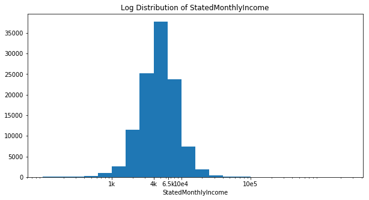

The linear scale for the StatedMonthlyIncome could not capture the distributions for low values. When plotted on a log scale, the StatedMonthlyIncome shows a normal distribution, with the peak values ranging from 4000 to 6500. As the value ranges above 6500, the plot slopes, indicating a decrease.

#### Distribution for the LoanOriginalAmount variable

```
Text(0.5,0,'LoanOriginalAmount')
```

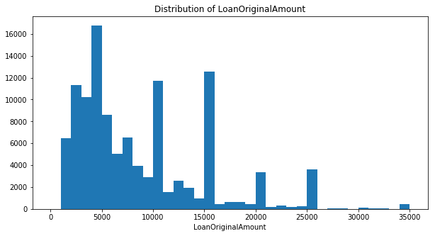

#### Distribution for the EmploymentStatus variable

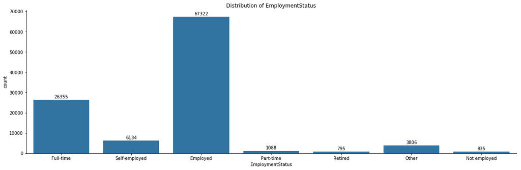

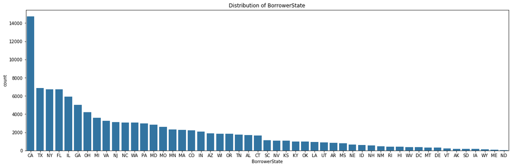

This plot shows that the state represented as CA has the highest number of borrowers.

#### Distribution for the LoanStatus variable

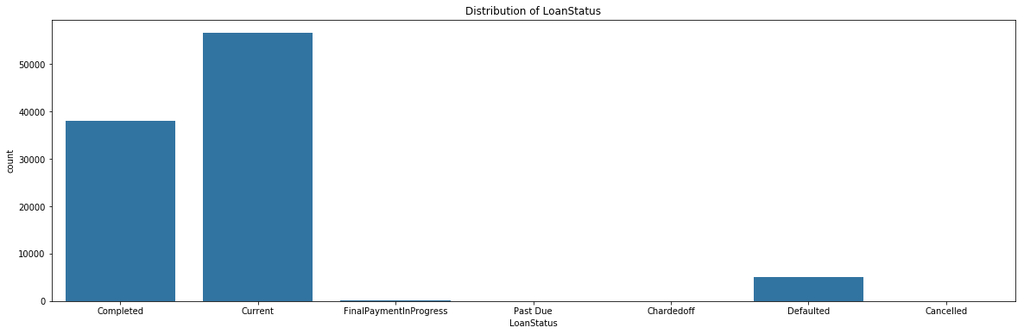

The bar chart above shows the distribution for the LoanStatus of the borrowers. There are more number of people with a current LoanStatus, followed by completed LoanStatus. There are least number of borrowers with cancelled LoanStatus